# Graph Types

QUARC data visualization workshop

[figure not shown]

## Data preparation

### Data preparation

Make sure you're data is “tidy”:

- Observations are rows.
- Variables are columns.
- First row (and only first row) consists of variable names.
- No extra stuff outside the rectangle.

## Identifying variable types

### Identifying variable types

- Categorical (nominal, qualitative, factor)

Classifies data by category.

> color, species, sex
- Quantitative (numeric, scale, interval/ratio)

Numerical measurements, usually with meaningful units.

> height, GDP, score

### Identifying variable types

**CAREFUL!**

Numbers are not always quantitative.

> *Do you own a car?*

> > 0 = “No”, 1 = “Yes”

> *What is your zip code?*

## Data set

Risk factors associated with low infant birth weight, collected at Baystate Medical Center, Springfield, Mass during 1986.

189 women measured on 10 variables.

### Data set

| low | age | lwt | race | smoke | ptl | ht | ui | ftv | bwt |
| --- | --- | --- | --- | --- | --- | --- | --- | --- | --- |
| 0 | 19 | 182 | 2 | 0 | 0 | 0 | 1 | 0 | 2523 |
| 0 | 33 | 155 | 3 | 0 | 0 | 0 | 0 | 3 | 2551 |
| 0 | 20 | 105 | 1 | 1 | 0 | 0 | 0 | 1 | 2557 |
| 0 | 21 | 108 | 1 | 1 | 0 | 0 | 1 | 2 | 2594 |
| 0 | 18 | 107 | 1 | 1 | 0 | 0 | 1 | 0 | 2600 |
| 0 | 21 | 124 | 3 | 0 | 0 | 0 | 0 | 0 | 2622 |
| 0 | 22 | 118 | 1 | 0 | 0 | 0 | 0 | 1 | 2637 |
| 0 | 17 | 103 | 3 | 0 | 0 | 0 | 0 | 1 | 2637 |
| 0 | 29 | 123 | 1 | 1 | 0 | 0 | 0 | 1 | 2663 |
| 0 | 26 | 113 | 1 | 1 | 0 | 0 | 0 | 0 | 2665 |
| 0 | 19 | 95 | 3 | 0 | 0 | 0 | 0 | 0 | 2722 |
| 0 | 19 | 150 | 3 | 0 | 0 | 0 | 0 | 1 | 2733 |
| 0 | 22 | 95 | 3 | 0 | 0 | 1 | 0 | 0 | 2751 |
| 0 | 30 | 107 | 3 | 0 | 1 | 0 | 1 | 2 | 2750 |
| 0 | 18 | 100 | 1 | 1 | 0 | 0 | 0 | 0 | 2769 |
| 0 | 18 | 100 | 1 | 1 | 0 | 0 | 0 | 0 | 2769 |
| 0 | 15 | 98 | 2 | 0 | 0 | 0 | 0 | 0 | 2778 |
| 0 | 25 | 118 | 1 | 1 | 0 | 0 | 0 | 3 | 2782 |
| 0 | 20 | 120 | 3 | 0 | 0 | 0 | 1 | 0 | 2807 |
| 0 | 28 | 120 | 1 | 1 | 0 | 0 | 0 | 1 | 2821 |
| 0 | 32 | 121 | 3 | 0 | 0 | 0 | 0 | 2 | 2835 |
| 0 | 31 | 100 | 1 | 0 | 0 | 0 | 1 | 3 | 2835 |
| 0 | 36 | 202 | 1 | 0 | 0 | 0 | 0 | 1 | 2836 |
| 0 | 28 | 120 | 3 | 0 | 0 | 0 | 0 | 0 | 2863 |
| 0 | 25 | 120 | 3 | 0 | 0 | 0 | 1 | 2 | 2877 |
| 0 | 28 | 167 | 1 | 0 | 0 | 0 | 0 | 0 | 2877 |
| 0 | 17 | 122 | 1 | 1 | 0 | 0 | 0 | 0 | 2906 |
| 0 | 29 | 150 | 1 | 0 | 0 | 0 | 0 | 2 | 2920 |
| 0 | 26 | 168 | 2 | 1 | 0 | 0 | 0 | 0 | 2920 |
| 0 | 17 | 113 | 2 | 0 | 0 | 0 | 0 | 1 | 2920 |

[output cut: 159 more lines]

## Single variable

- Single variables usually won't answer very interesting questions by themselves.
- Graphs of single variables are often valuable for exploring your data, but generally not suitable for inclusion in the final product.

### Single categorical variable

### Single categorical variable

Mother's race (white, black, or other)

```
# A tibble: 189 x 1
   race
   <fct>
 1 Black
 2 Other
 3 White
 4 White
 5 White
 6 Other
 7 White
 8 Other
 9 White
10 White
# ... with 179 more rows
```

### Single categorical variable

- Frequency table

| Race | Count |
| --- | --- |
| White | 96 |
| Black | 26 |
| Other | 67 |

### Single categorical variable

- Bar chart

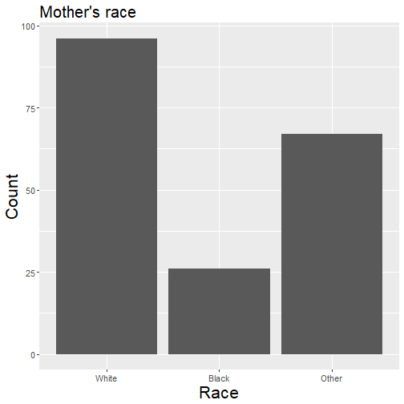

### Single categorical variable

- Pie chart **Danger! Danger!**

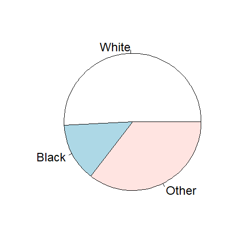

### Single categorical variable

- Relative frequency table

| Race | Count | Percent |
| --- | --- | --- |
| White | 96 | 0.51 |
| Black | 26 | 0.14 |
| Other | 67 | 0.35 |

### Single categorical variable

[Click here to see how to improve a pie chart.](http://www.statschat.org.nz/wp-content/uploads/2015/06/devourThePie3.gif)

### Single categorical variable

- Why do pie charts suck?

> [“Pie Charts Are the Worst”](http://www.businessinsider.com/pie-charts-are-the-worst-2013-6)

> [“Countdown of Top 10 Reasons to Never Ever Use a Pie Chart”](https://blogs.oracle.com/experience/entry/countdown_of_top_10_reasons_to_never_ever_use_a_pie_chart)

> [“Save the Pies for Dessert”](http://www.perceptualedge.com/articles/visual_business_intelligence/save_the_pies_for_dessert.pdf)
- And to be fair, one guy who defends pie charts:

> [“Why Tufte is Flat-Out Wrong about Pie Charts”](http://speakingppt.com/2013/03/18/why-tufte-is-flat-out-wrong-about-pie-charts/)

### Single quantitative variable

### Single quantitative variable

Infant birth weight in grams

```
# A tibble: 189 x 1
     bwt
   <int>
 1  2523
 2  2551
 3  2557
 4  2594
 5  2600
 6  2622
 7  2637
 8  2637
 9  2663
10  2665
# ... with 179 more rows
```

### Single quantitative variable

- Histogram

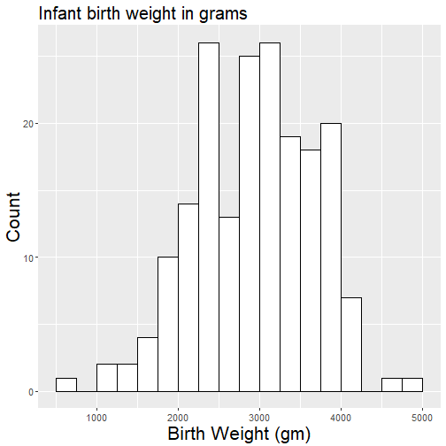

### Single quantitative variable

- Tabular summaries

(“Five-number summary” or other quantiles)

|  | Birth Weight (gm) |
| --- | --- |
| 0% | 709 |
| 5% | 1801 |
| 25% | 2414 |
| 50% | 2977 |
| 75% | 3487 |
| 95% | 3997 |
| 100% | 4990 |

### Single quantitative variable

- A bunch of other types I don't prefer:

> boxplot, stem-and-leaf plot, dotplot

## Multiple variables

There are at least six elements of a plot that can be assigned to variables:

- x-axis (horizontal axis)
- y-axis (vertical axis)
- facets
- color/fill
- size
- shape (e.g., dots vs crosses, solid vs dashed lines, etc.)

### Two categorical variables

### Two categorical variables

Mother's race and the number of previous premature labors.

```
# A tibble: 189 x 2
   race  ptl
   <fct> <fct>
 1 Black 0
 2 Other 0
 3 White 0
 4 White 0
 5 White 0
 6 Other 0
 7 White 0
 8 Other 0
 9 White 0
10 White 0
# ... with 179 more rows
```

### Two categorical variables

- Contingency table (okay)

|  | White | Black | Other |
| --- | --- | --- | --- |
| 0 | 82 | 22 | 55 |
| 1 | 10 | 4 | 10 |
| 2 | 3 | 0 | 2 |
| 3 | 1 | 0 | 0 |
| Total | 96 | 26 | 67 |

### Two categorical variables

- Contingency table (better)

|  | White | Black | Other |
| --- | --- | --- | --- |
| 0 | 85.42 | 84.62 | 82.09 |
| 1 | 10.42 | 15.38 | 14.93 |
| 2 | 3.12 | 0.00 | 2.99 |
| 3 | 1.04 | 0.00 | 0.00 |
| Total | 100.00 | 100.00 | 100.00 |

### Two categorical variables

- Side-by-side bar chart (okay)

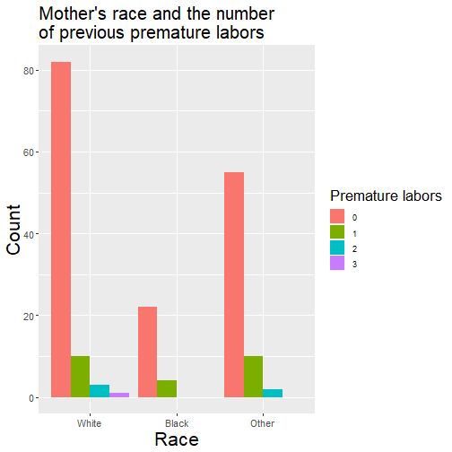

### Two categorical variables

- Side-by-side bar chart (better)

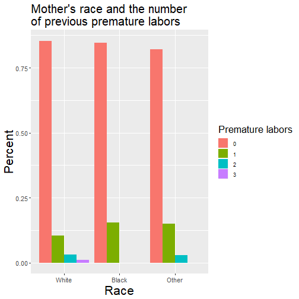

### Two categorical variables

- Stacked bar chart **Danger! Danger!**

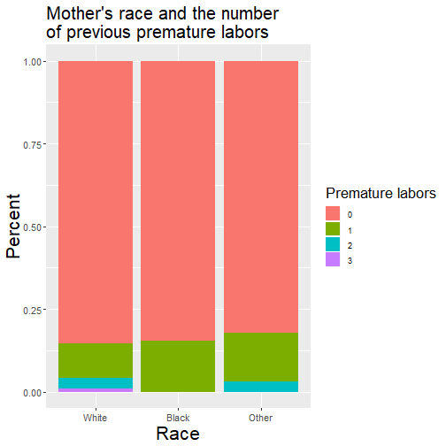

### One categorical and one quantitative variable

### One categorical and one quantitative variable

Mother's race and infant birth weight in grams

```
# A tibble: 189 x 2
   race    bwt
   <fct> <int>
 1 Black  2523
 2 Other  2551
 3 White  2557
 4 White  2594
 5 White  2600
 6 Other  2622
 7 White  2637
 8 Other  2637
 9 White  2663
10 White  2665
# ... with 179 more rows
```

### One categorical and one quantitative variable

- Side-by-side boxplot

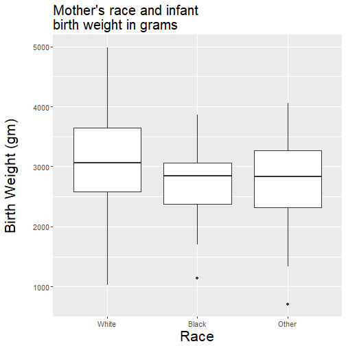

### One categorical and one quantitative variable

- Stacked histogram (okay)

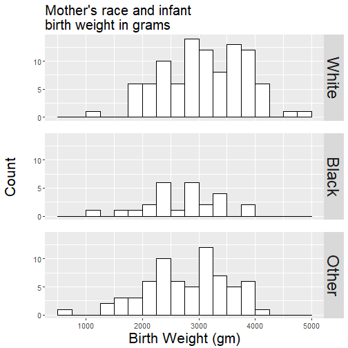

### One categorical and one quantitative variable

- Stacked histogram (better)

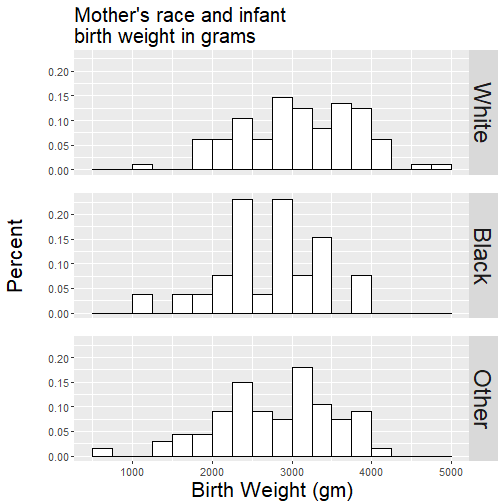

### Two quantitative variables

### Two quantitative variables

Mother's age and infant birth weight

```
# A tibble: 189 x 2
     age   bwt
   <int> <int>
 1    19  2523
 2    33  2551
 3    20  2557
 4    21  2594
 5    18  2600
 6    21  2622
 7    22  2637
 8    17  2637
 9    29  2663
10    26  2665
# ... with 179 more rows
```

### Two quantitative variables

- Scatterplot

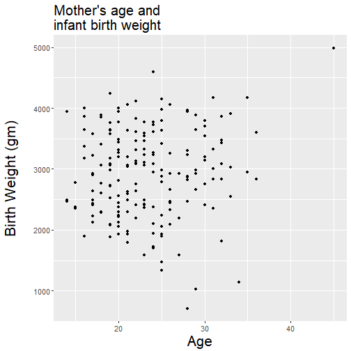

### Two quantitative variables

- If one variable is ordered (like time) and there is only one observation of y for each x value, use a lineplot.

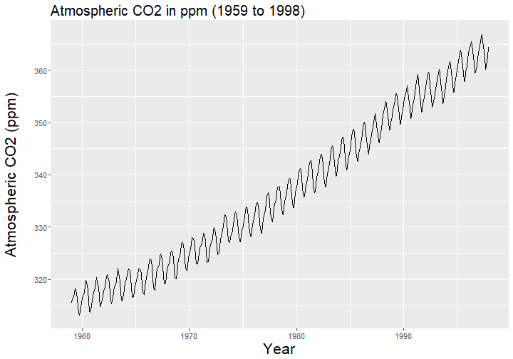

### Three or more variables

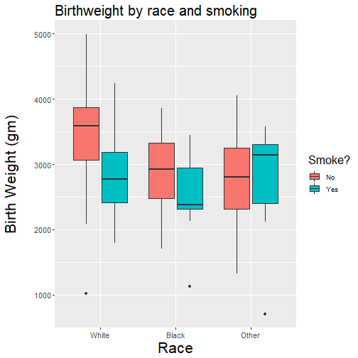

### Three or more variables

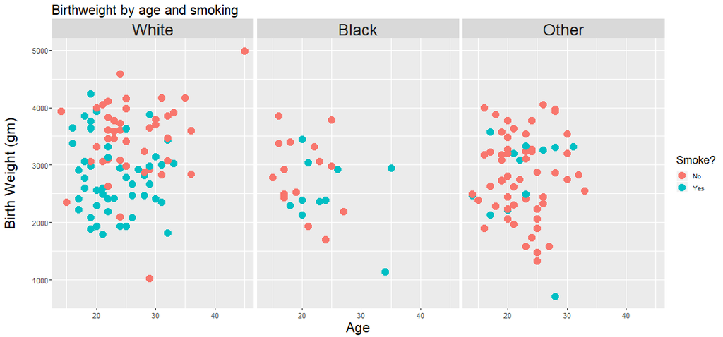